# Distributions

2023-11-11

### Distributions of variables for all countries

To perform an aggregated analysis, as opposed to do it per country, we study the distributions of our co-variables aggregated by county, for each year.

#### Types of variables

To aggregate data, we inspect the measurement type of each co-variable. The following table presents this information:

| Covariable | Description | Scale | Type |
| --- | --- | --- | --- |
| COV1 | Current health expenditure (CHE) as percentage of gross domestic product (GDP) (%) | 2.19 - 16.79 | Percentage of GDP |
| COV2 | Domestic general government health expenditure (GGHE-D) as percentage of current health expenditure (CHE) (%) | 7.13 - 91.8 | Percentage of GDP |
| COV3 | Domestic general government health expenditure (GGHE-D) as percentage of general government expenditure (GGE) (%) | 2.78 - 33.1 | Percentage of GDP |
| COV4 | Domestic general government health expenditure (GGHE-D) per capita in US | 2.41 - 5495.17 | Dolars per capita |
| COV5 | Current health expenditure (CHE) per capita in US | 18.5 - 10661.03 | Dolars per capita |
| COV6 | Domestic private health expenditure (PVT-D) per capita in US | 9.44 - 5165.86 | Dolars per capita |
| COV7 | Domestic general government health expenditure (GGHE-D) as percentage of gross domestic product (GDP) (%) | 0.29 - 11.57 | Percentage of GDP |
| COV8 | Domestic private health expenditure (PVT-D) as percentage of current health expenditure (CHE) (%) | 8.1 - 71.05 | Percentage of GDP |
| COV9 | External health expenditure (EXT) as percentage of current health expenditure (CHE) (%) | 0 - 64.68 | Percentage of GDP |
| COV13 | Out-of-pocket expenditure as percentage of current health expenditure (CHE) (%) | 8.1 - 63.93 | Percentage of GDP |
| COV21 | Healthcare access and quality (HAQ) index | 19.6954518128351 - 94.4992117998023 | Index |
| ECON1 | Poverty headcount ratio at national poverty line (% of population) | 16.7 - 64.4 | Percentage of Population |
| ECON2 | Gini index | 32.5 - 61.6 | Index |
| ECON3 | Unemployment rate (%); female | 1.2 - 28.431 | Population Rate |
| ECON4 | Unemployment rate (%); male | 1.2 - 22.621 | Population Rate |
| ECON5 | Unemployment rate (%) | 1.2 - 22.21 | Population Rate |
| ECON6 | Inflation (%) | -7.11376771265012 - 96.0941136930836 | Index |
| ECON7 | Annual GDP growth (%) | -11.9626972488343 - 14.4409895389734 | Index |
| ECON8 | Population pushed below a relative poverty line by household health expenditures - 60% of median daily per capita consumption or income (%, national, rural, urban) | 0.66 - 1.31 | Index |
| HEALTH1 | Public health expenditure as % of GDP | 0.29385616 - 11.57496323 | Percentage of GDP |
| HEALTH2 | Private health expenditure as % of GDP | 0.98137669 - 8.35827171 | Percentage of GDP |
| HEALTH3 | Out-of-pocket expenditure as % of current health expenditure | 8.0996418 - 63.93407059 | Percentage of GDP |
| HEALTH13 | Total alcohol per capita (age 15+ years) consumption | 1.61742 - 11.6419 | Per capita measurement |
| HEALTH14 | Total alcohol per capita (age 15+ years) consumption; male | 2.61882 - 18.71437 | Per capita measurement |
| HEALTH15 | Total alcohol per capita (age 15+ years) consumption; female | 0.68468 - 5.00793 | Per capita measurement |
| HEALTH16 | Healthcare access and quality (HAQ) index | 19.6954518128351 - 94.4992117998023 | Index |
| SOC1 | Population aged < 15 years (thousands) | 17.8585 - 62844.7655 | Total Population |
| SOC2 | Total population (thousands) 15-64 years | 48.7445 - 218886.775 | Total Population |
| SOC3 | Total population (thousands) 65-74 years | 2.9145 - 31189.467 | Total Population |
| SOC4 | Total population (thousands) 75+ years | 2.515 - 21526.6745 | Total Population |
| SOC5 | Total population (thousands) | 75.055 - 334319.671 | Total Population |
| SOC6 | Total population (thousands); female | 39.748 - 168620.84 | Total Population |
| SOC7 | Total population (thousands); male | 35.307 - 165698.83 | Total Population |
| SOC11 | Urban Population (%) | 18.45 - 95.426 | Percentage of Population |
| SOC13 | Homicide mortality rate (age-adjusted per 100 000 pop); female | 0.680321 - 69.391918 | Rate per 100000 |
| SOC14 | Homicide mortality rate (age-adjusted per 100 000 pop); male | 2.143285 - 198.573116 | Rate per 100000 |
| SOC20 | Proportion of the country with population density between 300 and 500 people per km2 | 0 - 0.389993341771 | Proportion |
| SOC21 | Proportion of the country with population density between 500 and 1000 people per km2 | 0 - 0.725809889967 | Proportion |
| SOC22 | Proportion of the country with population density over 1000 people per km2 | 0 - 0.808053135614 | Proportion |
| SOC23 | Proportion of the country with population density between 150 and 300 people per km2 | 0 - 0.617056989862 | Proportion |
| SOC24 | Proportion of the country with population density under 150 people per km2 | 0 - 1 | Proportion |
| SOC25 | Socio-demographic index | 0.358868829009446 - 0.866294754592673 | Index |
| WHO_COV_1 | Pharmacists | 0.67 - 11.66 | Rate per 100000 |
| WHO_COV_2 | Dentists | 0.01 - 12.94 | Rate per 100000 |
| WHO_COV_3 | Personal care workers | 80.15 - 140.09 | Rate per 100000 |
| WHO_COV_4 | Medical Doctors Total | 8.92 - 84.27 | Rate per 100000 |
| WHO_COV_5 | Midwifery Personnel Total | 0.84 - 7.3 | Rate per 100000 |
| WHO_COV_6 | Midwifery Personnel not further defined | 0.84 - 7.3 | Rate per 100000 |
| WHO_COV_7 | Nursing Personnel not further defined | 5.02 - 13.96 | Rate per 100000 |
| WHO_COV_8 | Nursing Personnel Total | 5.02 - 69.27 | Rate per 100000 |
| WHO_COV_9 | Medical Doctors not further defined | 1.77 - 84.27 | Rate per 100000 |
| WHO_COV_10 | Nursing Professionals | 11.74 - 17.24 | Rate per 100000 |
| WHO_COV_11 | Nursing Associate Professionals | 9.03 - 11.98 | Rate per 100000 |
| WHO_COV_12 | General Medical Practitioners | 6.07 - 8.92 | Rate per 100000 |
| WHO_COV_13 | Specialist Medical Practitioners | 8.96 - 15.95 | Rate per 100000 |

We can see that all co-variables deal with rates, percentages and indexes, except for total population co-variables such as `SOC1` through `SOC7`. We decided to perform the aggregation using means and medians for all variables, except for these, which either can be removed, or summed.

#### Distribution Inspection

The following code creates distribution plots for each variable at each year.

We read the data, remove redundant co-variables, and initialize some plotting values.

We create a list of grid-plots per variable.

```r
list_of_figures_per_var <- list()

for (var in variables) {

  data_graph <- Data_used[which(Imputed_data$Indicator == var), ]
  years <- unique(data_graph$Year)
  list_of_figures <-list()

  for (year in years) {

    data_plot <- data_graph[which(data_graph$Year == year), ]
    median_line <- median(data_plot$Value)
    dist_plot <- ggplot(data_plot, aes(x=Value)) +
      geom_histogram(aes(y=..density..),
                     colour="black", fill="white") +
      geom_density(alpha=.2, fill="#FF6666")+ geom_vline(
        xintercept = median_line, color = "blue", size=1.75) +
      ggtitle(paste("Distribution of ", var, sep=""))
    list_of_figures[[year]] <- dist_plot
  }

  plot_list <- lapply(names(list_of_figures), function(obj_name) {
    figure  <- list_of_figures[[obj_name]]
    # Add the title equal to the object's name
    figure +
      theme_bw() +
      labs(x = "", y = "", subtitle = obj_name)
  })
  list_of_figures_per_var[[var]] <- plot_list
}
```

We can see how some of these figures look like.

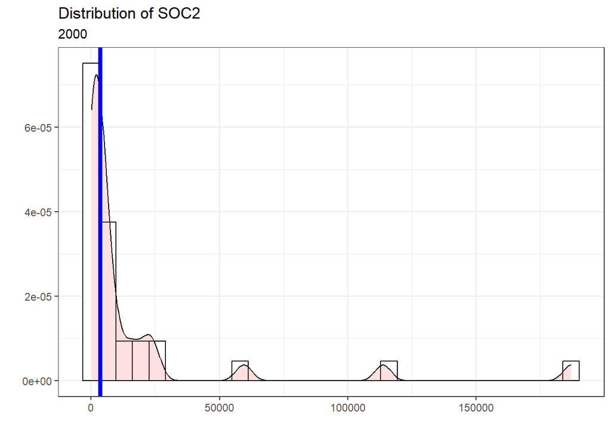

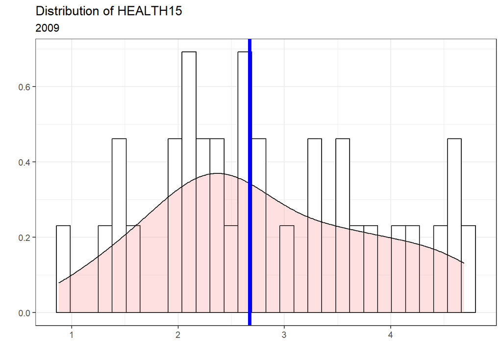

We stored the grid plots in the `./Figures/Distributions/` path of the main project.

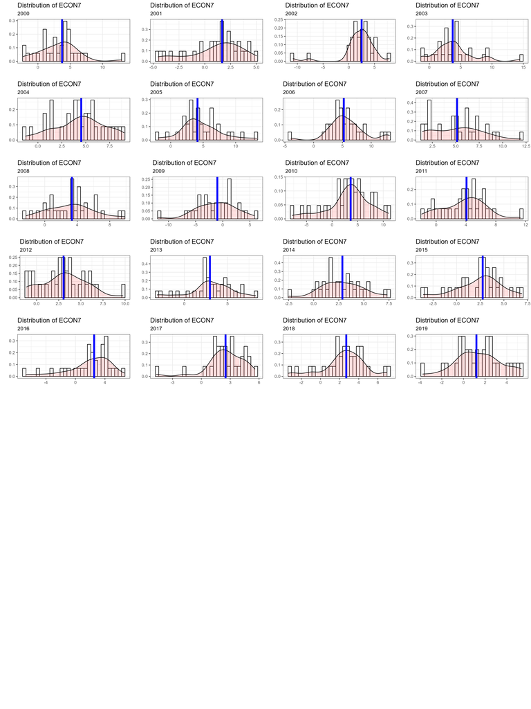

This way we have the distribution of each variable per year, over all countries. This is useful for aggregate analysis.

We also created heatmaps and lineplots to further inspect the shape and attributes of each variable across countries and years.

```r
list_of_heatmaps_per_var <- list()
list_of_lineplots_per_var <- list()

for (var in variables) {

  data_graph <- Data_used[which(Imputed_data$Indicator == var), ]
  data_graph <- subset(data_graph, select = -c(Indicator))
  data_graph_pivot <- spread(data_graph, key = Year, value = Value)

  # Heatmap
  heatmap <- ggplot(data_graph, aes(Year, Country, fill=Value)) +
    geom_tile() +
    ggtitle(paste("Heatmap of ", var, " for each country", sep="")) +
    scale_fill_distiller(palette = "Spectral") +
    theme(
      axis.text.x = element_text(
        angle = 90,
        hjust = 1,
        vjust = 0.5
      ))

  lineplot <- ggplot(data_graph, aes(x=Year, y=Value, group=Country, color=Country)) +
    geom_line(linewidth=0.9) +
    ggtitle(paste("Time Series of ", var, " for each country", sep="")) +
    theme(
      axis.text.x = element_text(
        angle = 90,
        hjust = 1,
        vjust = 0.5
      )) + scale_color_manual(values=colors)

  # all_graph <- plot_grid(lineplot, heatmap, labels = "AUTO")
  # save_plot(paste("./Figures/HeatmapsLinePlots/Plot_", var, ".png", sep=""), all_graph, ncol = 2)
  list_of_heatmaps_per_var[[var]] <- heatmap
  list_of_lineplots_per_var[[var]] <- lineplot
}
```

Here’s one example:

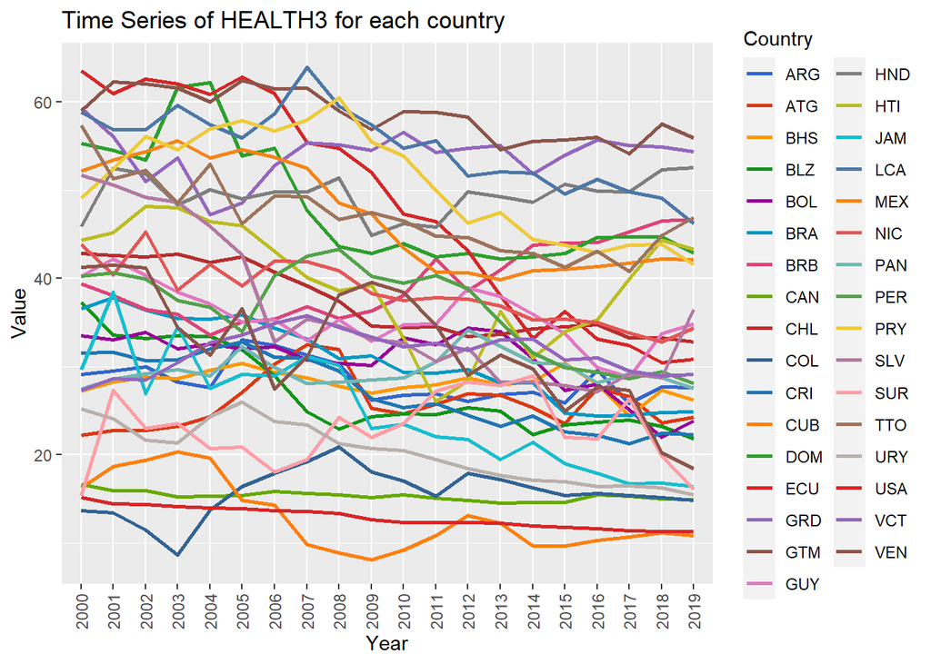

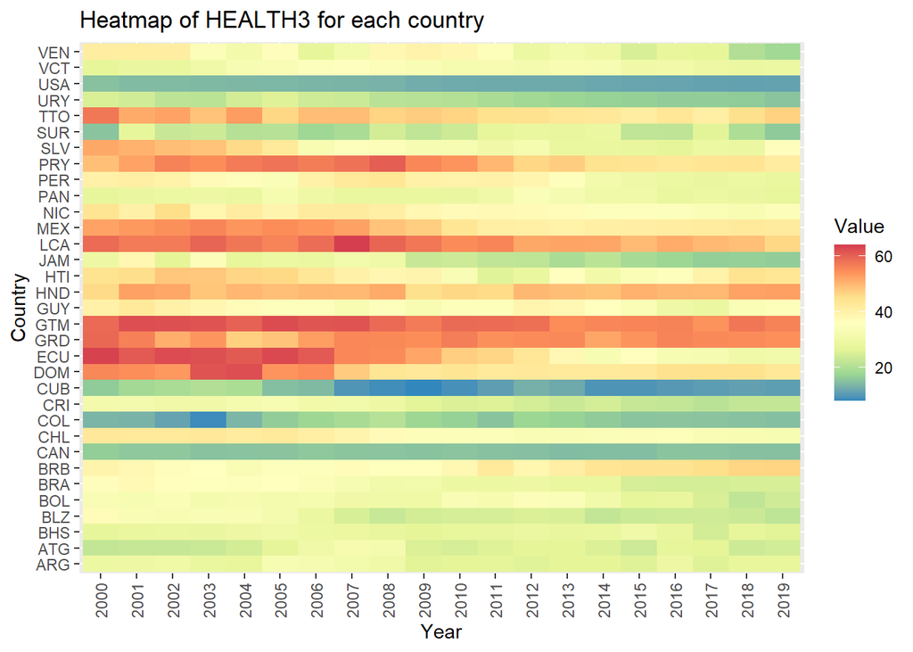

### Creation of aggregate data

- **Ubication**: Continent, Island.
- **Region**: North, Center, South, Island.
- **SubRegion**: Andean Area, Brazil, Central America, Latin Caribbean, Mexico, Non Latin Caribbean, North America, Southern Cone. These are the sub-regions specified by PAHO: [PAHO Dashboard Subregions](https://opendata.paho.org/en/core-indicators/subregions-dashboard).

For example let’s see the aggregate code applied to the *SubRegion* classification.

```r
region_column <- "SubRegion"
population_variable <- "SOC5"

Imputed_data_0 <- as.data.frame(
  read.xlsx("../Imputed_data/Final_imputed_data_All_with_Regions.xlsx"))

cat(paste("Aggregating by ", region_column, " ... \n"))
```

```
## Aggregating by  SubRegion  ...
```

```r
Imputed_data <- Imputed_data_0[, c("Country",
                                   "Indicator",
                                   "Year",
                                   "Value",
                                   region_column)]

if(region_column != "Region"){
  Imputed_data$Region <- Imputed_data[, c(region_column)]
}

Imputed_data <- Imputed_data[, c("Country",
                                 "Indicator",
                                 "Year",
                                 "Value",
                                 "Region")]

Aggregate_Data <- data.frame()
region_values <- unique(Imputed_data$Region)

for (region_use in region_values) {

  cat(paste("Processing ", region_use, " ... \n"))

  # Population Data
  pop_data <- Imputed_data[Imputed_data$Indicator == "SOC5",
                           c("Country", "Year", "Value", "Region")]

  pop_data <- pop_data[pop_data$Region == region_use,
                       c("Country", "Year", "Value")]
  colnames(pop_data) <- c("Country", "Year", "Population")
  total_pop <- pop_data %>% group_by(Year) %>%
    summarise(TotalPop=sum(Population), .groups = 'drop')
  pop_data <- merge(pop_data, total_pop, by.x=c("Year"),
                    by.y=c("Year"), all.x=TRUE)
  pop_data$PopWeight <- pop_data$Population/pop_data$TotalPop

  var_data <- Imputed_data[Imputed_data$Indicator != "SOC5", ]
  var_data <- var_data[var_data$Region == region_use, ]
  variables_region <- unique(var_data$Indicator)

  Aggregate_Data_Region <- data.frame()

  for (var in variables_region) {

    # cat(paste("Processing ", var, " for ", region_use, " ... \n"))

    indicator_data <- var_data[which(var_data$Indicator == var), ]
    indicator_data <- merge(indicator_data, pop_data, by.x=c("Country", "Year"),
                            by.y=c("Country", "Year"), all.x=TRUE)

    indicator_data$WeightedValueRaw <- indicator_data$Value * indicator_data$PopWeight

    Aggregate_Data_Region_Indicator <- indicator_data %>% group_by(Year, Region) %>%
      summarise(MedianValue=median(Value),
                WeightedValue=sum(WeightedValueRaw),
                MeanValue=mean(Value), .groups = 'drop')

    Aggregate_Data_Region_Indicator$Indicator <- var

    Aggregate_Data_Region <- rbind(Aggregate_Data_Region, Aggregate_Data_Region_Indicator)

  }

  Aggregate_Data <- rbind(Aggregate_Data, Aggregate_Data_Region)

}
```

```
## Processing  Southern Cone  ...
## Processing  Non Latin Caribbean  ...
## Processing  Central America  ...
## Processing  Andean Area  ...
## Processing  Brazil  ...
## Processing  North America  ...
## Processing  Latin Caribbean  ...
## Processing  Mexico  ...
```

To check computations, for example let’s inspect the values of region `Southern Cone` at year 2000 for indicator `SOC13`:

```r
data_ <- Imputed_data_0[Imputed_data_0$SubRegion == 'Southern Cone', ]
data_ <- data_[data_$Year == 2000, ]
data_ <- data_[data_$Indicator %in% c("SOC5", "SOC13"), ]
data_ <- data_ %>%
    pivot_wider(names_from = Indicator, values_from = Value)
kable(data_)%>%
  kable_styling(full_width = FALSE)%>%
  kable_styling(font_size = 14)
```

| Country | Year | Ubication | Region | SubRegion | SOC13 | SOC5 |
| --- | --- | --- | --- | --- | --- | --- |
| ARG | 2000 | Continent | South | Southern Cone | 2.204596 | 37070.774 |
| CHL | 2000 | Continent | South | Southern Cone | 1.286607 | 15351.799 |
| PRY | 2000 | Continent | South | Southern Cone | 5.461316 | 5123.819 |
| URY | 2000 | Continent | South | Southern Cone | 2.301432 | 3292.224 |

To compute the weights we divide the populations of each country by the total population of in this region over that year.

| Country | Year | Ubication | Region | SubRegion | SOC13 | SOC5 | Weights | SOC13_Weighted |
| --- | --- | --- | --- | --- | --- | --- | --- | --- |
| ARG | 2000 | Continent | South | Southern Cone | 2.204596 | 37070.774 | 0.6093297 | 1.3433258 |
| CHL | 2000 | Continent | South | Southern Cone | 1.286607 | 15351.799 | 0.2523364 | 0.3246578 |
| PRY | 2000 | Continent | South | Southern Cone | 5.461316 | 5123.819 | 0.0842198 | 0.4599512 |
| URY | 2000 | Continent | South | Southern Cone | 2.301432 | 3292.224 | 0.0541141 | 0.1245398 |

```r
median <- median(data_$SOC13)
weighted_value <- sum(data_$SOC13_Weighted)
mean <- mean(data_$SOC13)
cat(paste(median, weighted_value, mean))
```

```
## 2.253014 2.25247458758544 2.81348775
```

Which agrees with the values at the computed aggregated data:

| Year | Region | MedianValue | WeightedValue | MeanValue | Indicator |
| --- | --- | --- | --- | --- | --- |
| 2000 | Southern Cone | 2.253014 | 2.252475 | 2.813488 | SOC13 |

Note that the total population variables (`SOC1`, … `SOC7`) are not present in this data, only `SOC5` which is used for the weighted values:

```
##  [1] "SOC13"      "HEALTH2"    "HEALTH1"    "HEALTH3"    "SOC5"
##  [6] "SOC11"      "SUICF"      "ECON5"      "ECON3"      "HEALTH13"
## [11] "HEALTH15"   "ECON7"      "HEALTH16"   "SOC23"      "SOC20"
## [16] "SOC21"      "SOC22"      "SOC24"      "SOC25"      "SOC14"
## [21] "SUICM"      "ECON4"      "HEALTH14"   "COV5"       "COV1"
## [26] "COV9"       "COV4"       "COV2"       "COV7"       "COV3"
## [31] "COV13"      "COV6"       "COV8"       "COV21"      "ECON2"
## [36] "CovIndex"   "ECON6"      "WHO_COV_1"  "WHO_COV_2"  "WHO_COV_4"
## [41] "WHO_COV_5"  "WHO_COV_6"  "WHO_COV_7"  "WHO_COV_8"  "ECON1"
## [46] "WHO_COV_9"  "WHO_COV_12" "WHO_COV_11" "WHO_COV_13" "WHO_COV_10"
## [51] "WHO_COV_3"  "ECON8"
```

```
##  [1] "SOC13"      "HEALTH2"    "HEALTH1"    "HEALTH3"    "SOC11"
##  [6] "SUICF"      "ECON5"      "ECON3"      "HEALTH13"   "HEALTH15"
## [11] "ECON7"      "HEALTH16"   "SOC23"      "SOC20"      "SOC21"
## [16] "SOC22"      "SOC24"      "SOC25"      "SOC14"      "SUICM"
## [21] "ECON4"      "HEALTH14"   "COV5"       "COV1"       "COV9"
## [26] "COV4"       "COV2"       "COV7"       "COV3"       "COV13"
## [31] "COV6"       "COV8"       "COV21"      "ECON2"      "CovIndex"
## [36] "ECON6"      "WHO_COV_2"  "WHO_COV_4"  "WHO_COV_5"  "WHO_COV_6"
## [41] "ECON1"      "WHO_COV_8"  "WHO_COV_9"  "WHO_COV_7"  "WHO_COV_1"
## [46] "WHO_COV_3"  "ECON8"      "WHO_COV_12" "WHO_COV_11" "WHO_COV_13"
## [51] "WHO_COV_10"
```

The `MainFileRegion` document contains the code to fit the models to aggregate data.